# IE 48B Homework 01 - Dorukhan Kılınç 2017402093

```python
import pandas as pd
import numpy as np
from mpl_toolkits import mplot3d
import matplotlib.pyplot as plt
```

## Part 1

```python
file_names = ["uWaveGestureLibrary_X_TRAIN",
              "uWaveGestureLibrary_Y_TRAIN",
              "uWaveGestureLibrary_Z_TRAIN"]

data = [[], [], []]

for i in range(3):
    for line in open(file_names[i]):
        data[i].append(line.split())
    data[i] = np.array(data[i])
```

```python
data_acc = np.ndarray(shape = (896, 316, 3), dtype = "float")

for i in range(3):
    data_acc[:,:, i] = data[i]

data_v = np.zeros(shape = (896, 316, 3))

data_v[:,0,:] = data_acc[:,0,:]

for instance in range(896):
    for time in range(2, 316):
        data_v[instance, time, :] = data_v[instance, time - 1,:] + data_acc[instance, time - 1,:]

data_dist = np.zeros(shape = (896, 316, 3))
data_dist[:,0,:] = data_acc[:,0,:]

for instance in range(896):
    for time in range(2, 316):
        data_dist[instance, time, :] = data_dist[instance, time - 1,:] + data_v[instance, time - 1,:] + data_acc[instance, time - 1,:]/2
```

```python
instances = []

for c in range(1,9):
    for instance in range(896):
        if data_v[instance,0,0] == c:
            instances.append(instance)
            break
instances
```

```
[10, 14, 3, 4, 1, 0, 6, 5]
```

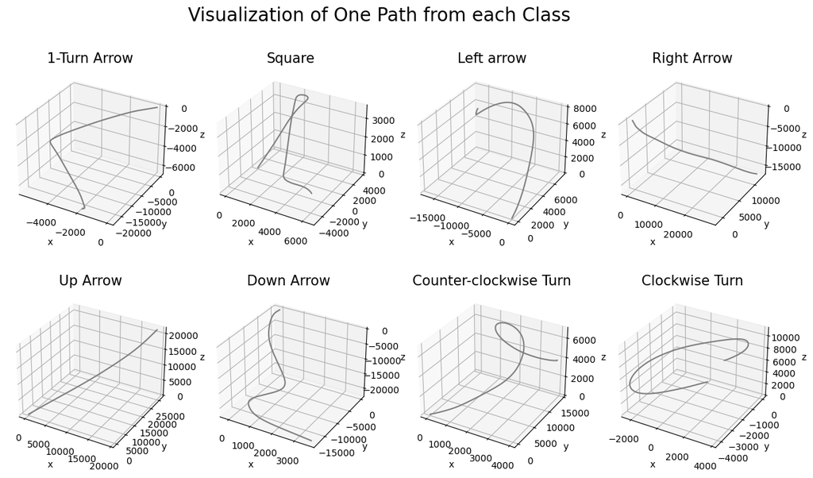

```python
fig = plt.figure(figsize= (15,8))

labels =["1-Turn Arrow", "Square", "Left arrow", "Right Arrow",
        "Up Arrow", "Down Arrow ", "Counter-clockwise Turn", "Clockwise Turn"]
for i in range(2):
    for j in range(4):
        ax = fig.add_subplot(2, 4, i*4 + j + 1, projection='3d')
        ax.plot(data_dist[instances[i*4 + j], 1:, 0],
                       data_dist[instances[i*4 + j], 1:, 1],
                       data_dist[instances[i*4 + j], 1:, 2],
                       'gray')
        ax.set_title(labels[i*4 + j], size =15)
        ax.set_xlabel('x')
        ax.set_ylabel('y')
        ax.set_zlabel('z')

fig.suptitle("Visualization of One Path from each Class",size = 20)

plt.show();
```

The class labels for each instance is in accordance with the numbers given in the homework. I decided on what class each instance belongs to by basically visualizing the path each instance follows and try to find the moves it makes. To construct the paths, I used basic physics knowledge to find the path from the acceleration data, i.e. $V_{t} = V_{t-1} + a_{t-1}\Delta t$ and $X_{t} = X_{t-1} + V_{t-1}\Delta t + \frac{1}{2}a_{t-1}(\Delta t)^2$. It should be noted that the t-1 velocity and acceleration used to calculate $X_{t}$ since we don't have continuous acceleration data. Furthermore, for easiness, I assumed $\Delta t = 1$. Therefore the equations became:

$V_{t} = V_{t-1} + a_{t-1}$

$X_{t} = X_{t-1} + V_{t-1} + \frac{1}{2}a_{t-1}$

Note that I assumed that $X_{t = 0} = (0, 0, 0)$.Here is some further explanation about why I labeled instances in the way I did:

Class 1: Since the path takes a sharp turn and in none of the other classes there is only one sharp turn

Class 2: Since the path takes three sharp turns.

Class 5: Since the path moves in the +z direction.

Class 6: Since the path moves in the -z direction.

## Part 2

### Proposition 1: Use projection to a plane to reduce the number of dimensions

My first proposition as an alternative time series representation is to find a surface in the space passing from the origin, the center of the path and the end of the path and project each point of the path onto this surface. Then, find a new basis in this surface to represent the points with 2 coordinates. By doing that, I would decrease the number of dimensions of the data from 3 to 2. Here is the explanation of my proposed attempt:

- Calculate the center by simply taking the mean of the paths with respect to each coordinate.
- Find two vectors, say $\vec{u_{1}}$ and $\vec{u_{2}}$ to represent the plane. I have chosen the vectors from origin to the center as $\vec{u_{1}}$ and from origin to the end point as $\vec{u_{2}}$ for calculation easiness.
- Find the normal of the plane by calculating $\vec{u_{1}}\times\vec{u_{2}}$, call it $\vec{n}$. Find the unit normal vector $\hat{n} = \frac{\vec{n}}{||\vec{n}||}$
- To project a point $P$ to the plane, calculate ${P'} =\vec{P} - (\hat{n}\cdot\vec{P})\hat{n}$ where $\vec{P}$ is the vector from origin to the point P. We can use origin as a reference point for our projection since the plane will pass from the origin by our construction.
- To construct the matrix for basis change, we need 3 perpendicular vectors: 2 in the plane and 1 being the normal $\vec{n}$. For the vectors in the plane, choose $\hat{u}_{1} = \frac{\vec{u_{1}}}{||\vec{u_{1}}||}$ and choose $\hat{u}_{3} = \hat{u}_{1}\times\hat{n}$ as two perpendicular bases.
- Find new coordinates by calculating $[\hat{u}_{1}\hat{u}_{3}\hat{n}]^{-1}\cdot (P' - P_{center})$. By doing this, we will change our coordinate system into a new one at which the new origin is the center of the path. Since we are applying a basis change to the points projected to a plane and one of our bases is the normal of the plane, the last coordinate will always be zero. So, omit the last coordinate to reduce the number of dimensions.

```python
c = [[],[],[],[],
    [],[],[],[]]
for instance in range(816):
    for i in range(8):
        if projected_pts[instance, 0, 0] == i+1:
            c[i].append(instance)


def projection(curve):

    cm = np.array([np.mean(curve[1:,0]),
                   np.mean(curve[1:,1]),
                   np.mean(curve[1:,2])])

    u1 = cm

    u1 = u1/np.linalg.norm(u1)

    u2 = curve[315, :] - curve[1, :]

    u2 = u2/np.linalg.norm(u2)

    u_normal = np.cross(u1, u2)
    u_normal = u_normal/np.linalg.norm(u_normal)

    u3 = np.cross(u1, u_normal)
    u3 = u3/np.linalg.norm(u3)

    proj_matrix = np.array([u1, u3, u_normal]).T

    proj = np.zeros(shape = (316, 3))
    proj[0,:] = curve[0,:]

    for i in range(1,316):
        point = curve[i,:] - np.dot(u_normal,  curve[i,:])*u_normal
        proj[i,:] = np.linalg.solve(proj_matrix, point) - np.linalg.solve(proj_matrix, cm)
    return proj[:, (0,1)]
```

```python
projected_pts = np.zeros(shape=(896,316,2))

for instance in range(896):
    projected_pts[instance,:,:] = projection(data_dist[instance,:,:])
```

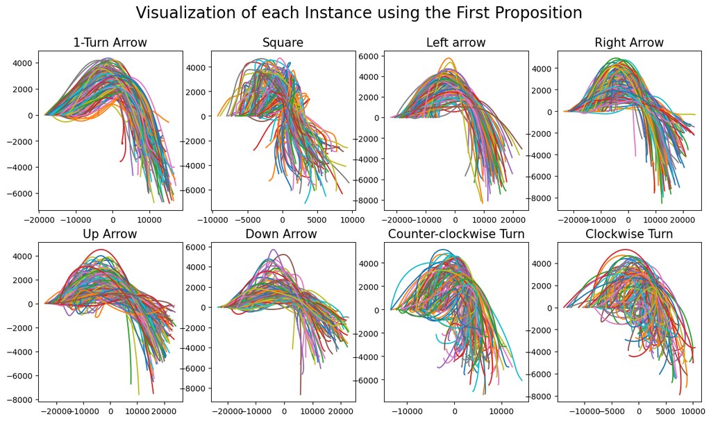

```python
fig = plt.figure(figsize= (15,8))

for i in range(8):
    ax = fig.add_subplot(2, 4, i+1)
    ax.set_title(labels[i], size =15)

    for instance in c[i]:
        ax.plot(projected_pts[instance, 1:, 0],
                       projected_pts[instance, 1:,1])

fig.suptitle("Visualization of each Instance using the First Proposition",size = 20)

plt.show();
```

Here above is the each path seperated by the class it belongs to. Notice that there is a visible difference between the arrows and other shapes. The latter tends to have a more circular path. Let's take means of the each time steps to try to find more visible differences:

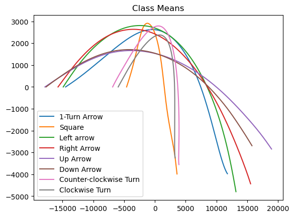

```python
for i in range(8):
    d = np.zeros(shape = (315,2))
    for time in range(315):

        for instance in c[i]:
                d[time, 0] += projected_pts[instance, time+1, 0]
                d[time, 1] += projected_pts[instance, time+1, 1]

        d[time] = d[time]/len(c[i])
    plt.plot(d[:,0], d[:,1])

plt.legend(labels)
plt.title("Class Means")
plt.show();
```

### Propositon 2: Construct a 1-dimensional time series denoting the distance from the origin plus the distance from the end

The other representation I propose is to plot the distance from origin plus the distance from the end of the path for each time step. Therefore, we will get a 1-dimensional representation of the data. I prefered to use both of the distances because I thought that I would seperate arrows from circular ones more accurately since straight lines will have more straight sum of distances.

```python
data_dist_origin =  np.zeros(shape = (896, 315))

for instance in range(896):
    for time in range(315):
        data_dist_origin[instance, time] = np.linalg.norm(data_dist[instance, time  + 1, :])
```

```python
data_dist_end = np.zeros(shape = (896, 315))

for instance in range(896):
    for time in range(315):
        data_dist_end[instance, time] = np.linalg.norm(data_dist[instance, time  + 1, :] -data_dist[instance, 315, :])
```

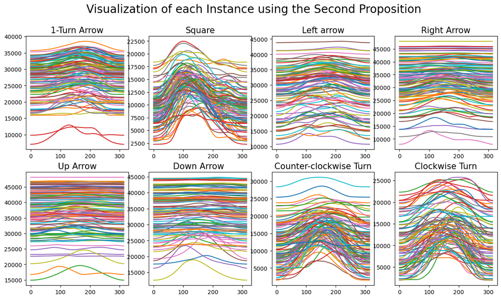

```python
fig = plt.figure(figsize= (15,8))
for i in range(8):
    ax = fig.add_subplot(2, 4, i+1)
    ax.set_title(labels[i], size =15)

    for instance in c[i]:
        ax.plot(data_dist_origin[instance,:] + data_dist_end[instance,:] )

fig.suptitle("Visualization of each Instance using the Second Proposition",size = 20)

plt.show();
```

Notice that apart from some outliers, arrows have very straight lines. Further, 1-turn arrow is also straight-like apart from a bump around the middle. In addition, square has a characteristic bump before the middle. For further inspection, I will take the class means.

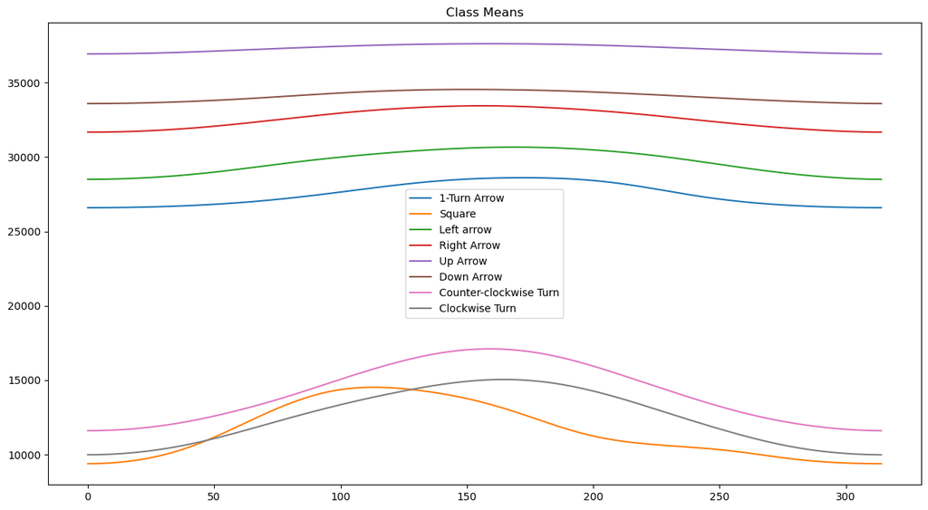

```python
fig = plt.figure(figsize= (15,8))
for i in range(8):
    d = np.zeros(shape = 315)
    for time in range(315):

        for instance in c[i]:
                d[time] += data_dist_origin[instance,time] +data_dist_end[instance,time]

        d[time] = d[time]/len(c[i])
    plt.plot(d)

plt.legend(labels)
plt.title("Class Means")

plt.show();
```

## Conclusion

In conclusion, to perform a better analysis, I transformed the accelaration data to paths and worked with them. This made visual representations more understandable. Then, I proposed two approaches to represent the data with less features. The first one was to use linear algebra to reduce the number of dimensions and the second one was to deal with the normed distances and therefore, get 1-dimensional data.

The former offered a easier visualization from the 3-dimensional data and we were able to tell the arrows apart from the other shapes. However, we lost the orientation of the paths since we chose our bases by using the points in the path.For example, the direction of turns were not distinguishable. This approach may be improved by selecting a better set of bases for the coordinate change.

The latter did not give much clue about the shapes visually, however it was more successful in the sense that it seperated each class more accurately.